# Sakila Database Analysis

Eugenia Bening (M0724025)

2026-05-26

# 1 Pendahuluan

**Latar Belakang**

Database **Sakila** adalah contoh basis data MySQL yang merepresentasikan sistem persewaan film (DVD rental store). Database ini mencakup informasi tentang film, pelanggan, staf, pembayaran, dan transaksi rental. Dalam analisis ini, kami mengeksplorasi **pendapatan rental berdasarkan kategori genre film** serta **tren pendapatan bulanan** untuk memahami pola bisnis penyewaan film.

## 1.1 Deskripsi Insight

Insight yang diambil dalam analisis ini adalah:

> **“Bagaimana distribusi pendapatan rental film berdasarkan kategori genre, dan bagaimana tren pendapatan bulanan pada toko penyewaan film Sakila?”**

Pertanyaan analitik yang akan dijawab:

1. Genre film apa yang menghasilkan pendapatan terbesar?
2. Bagaimana tren pendapatan dari bulan ke bulan?
3. Apakah ada korelasi antara jumlah rental dan total pendapatan per genre?
4. Bagaimana distribusi rating film berpengaruh terhadap volume rental?

## 1.2 Variabel yang Digunakan

| Tabel | Variabel | Deskripsi |
| --- | --- | --- |
| `payment` | `amount`, `payment_date` | Jumlah pembayaran dan tanggal |
| `rental` | `rental_id`, `rental_date` | ID dan tanggal rental |
| `inventory` | `inventory_id`, `film_id` | Relasi inventori ke film |
| `film` | `title`, `rating`, `rental_rate` | Detail film |
| `film_category` | `category_id` | Relasi film ke kategori |
| `category` | `name` | Nama kategori/genre |

# 2 Persiapan Data

## 2.1 Instalasi & Loading Package

```r
packages <- c("RMySQL", "DBI", "dplyr", "ggplot2", "tidyr", "lubridate",
               "scales", "viridis", "knitr", "kableExtra",
               "plotly", "gridExtra", "RColorBrewer", "forcats")

for (pkg in packages) {
  if (!requireNamespace(pkg, quietly = TRUE)) {
    install.packages(pkg, repos = "https://cran.r-project.org")
  }
}

library(DBI);      library(dplyr);     library(ggplot2)
library(tidyr);    library(lubridate); library(scales)
library(knitr);    library(kableExtra);library(gridExtra)
library(RColorBrewer); library(forcats)
```

## 2.2 Koneksi Database

```
## Koneksi berhasil!
```

```
##  [1] "actor"                      "actor_info"
##  [3] "address"                    "category"
##  [5] "city"                       "country"
##  [7] "customer"                   "customer_list"
##  [9] "film"                       "film_actor"
## [11] "film_category"              "film_list"
## [13] "film_text"                  "inventory"
## [15] "language"                   "nicer_but_slower_film_list"
## [17] "payment"                    "rental"
## [19] "sales_by_film_category"     "sales_by_store"
## [21] "staff"                      "staff_list"
## [23] "store"
```

## 2.3 Pengambilan Data via SQL

```r
# QUERY 1: Pendapatan per Genre
query_genre <- "
  SELECT c.name AS genre,
    COUNT(r.rental_id)  AS total_rental,
    SUM(p.amount)       AS total_pendapatan,
    AVG(p.amount)       AS rata_pendapatan,
    AVG(f.rental_rate)  AS rata_rental_rate
  FROM category c
  JOIN film_category fc ON c.category_id  = fc.category_id
  JOIN film          f  ON fc.film_id     = f.film_id
  JOIN inventory     i  ON f.film_id      = i.film_id
  JOIN rental        r  ON i.inventory_id = r.inventory_id
  JOIN payment       p  ON r.rental_id    = p.rental_id
  GROUP BY c.name ORDER BY total_pendapatan DESC;"

# QUERY 2: Tren Bulanan
query_bulanan <- "
  SELECT DATE_FORMAT(p.payment_date, '%Y-%m') AS bulan,
    COUNT(r.rental_id) AS total_rental,
    SUM(p.amount)      AS total_pendapatan
  FROM payment p
  JOIN rental r ON p.rental_id = r.rental_id
  GROUP BY DATE_FORMAT(p.payment_date, '%Y-%m') ORDER BY bulan;"

# QUERY 3: Distribusi Rating
query_rating <- "
  SELECT f.rating, c.name AS genre,
    COUNT(r.rental_id) AS total_rental,
    SUM(p.amount)      AS total_pendapatan
  FROM film f
  JOIN film_category fc ON f.film_id      = fc.film_id
  JOIN category      c  ON fc.category_id = c.category_id
  JOIN inventory     i  ON f.film_id      = i.film_id
  JOIN rental        r  ON i.inventory_id = r.inventory_id
  JOIN payment       p  ON r.rental_id    = p.rental_id
  GROUP BY f.rating, c.name ORDER BY total_pendapatan DESC;"

# QUERY 4: Top 10 Film
query_top_film <- "
  SELECT f.title, c.name AS genre, f.rating,
    COUNT(r.rental_id) AS total_rental,
    SUM(p.amount)      AS total_pendapatan
  FROM film f
  JOIN film_category fc ON f.film_id      = fc.film_id
  JOIN category      c  ON fc.category_id = c.category_id
  JOIN inventory     i  ON f.film_id      = i.film_id
  JOIN rental        r  ON i.inventory_id = r.inventory_id
  JOIN payment       p  ON r.rental_id    = p.rental_id
  GROUP BY f.title, c.name, f.rating
  ORDER BY total_pendapatan DESC LIMIT 10;"

df_genre    <- dbGetQuery(con, query_genre)
df_bulanan  <- dbGetQuery(con, query_bulanan)
df_rating   <- dbGetQuery(con, query_rating)
df_top_film <- dbGetQuery(con, query_top_film)
dbDisconnect(con)
```

# 3 Eksplorasi Data (EDA)

## 3.1 Gambaran Umum Dataset

```r
cat("=== RINGKASAN DATA GENRE ===\n")
```

```
## === RINGKASAN DATA GENRE ===
```

```r
cat("Jumlah genre    :", nrow(df_genre), "\n")
```

```
## Jumlah genre    : 16
```

```r
cat("Total rental    :", sum(df_genre$total_rental), "\n")
```

```
## Total rental    : 16190
```

```r
cat(sprintf("Total pendapatan: $%s\n",
            format(sum(df_genre$total_pendapatan), big.mark=",")))
```

```
## Total pendapatan: $67,927.99
```

```r
df_genre %>%
  mutate(
    total_pendapatan    = dollar(total_pendapatan),
    rata_pendapatan     = dollar(rata_pendapatan),
    rata_rental_rate    = dollar(rata_rental_rate),
    total_rental        = format(total_rental, big.mark = ",")
  ) %>%
  rename(
    Genre                  = genre,
    `Total Rental`         = total_rental,
    `Total Pendapatan`     = total_pendapatan,
    `Rata-rata/Transaksi`  = rata_pendapatan,
    `Rata-rata Rental Rate`= rata_rental_rate
  ) %>%
  kable(caption = "Tabel 1. Ringkasan Pendapatan per Genre Film",
        align   = c("l","r","r","r","r")) %>%
  kable_styling(bootstrap_options = c("striped","hover","condensed","responsive"),
                full_width = TRUE) %>%
  row_spec(1:3, bold = TRUE, background = "#e6efca") %>%
  column_spec(3, bold = TRUE, color = "#4a5c02")
```

Tabel 1. Ringkasan Pendapatan per Genre Film

| Genre | Total Rental | Total Pendapatan | Rata-rata/Transaksi | Rata-rata Rental Rate |
| --- | --- | --- | --- | --- |
| Sports | 1,179 | $5,314.21 | $4.51 | $3.08 |
| Animation | 1,166 | $5,251.61 | $4.50 | $2.91 |
| Action | 1,112 | $4,945.70 | $4.45 | $2.98 |
| Sci-Fi | 1,101 | $4,756.98 | $4.32 | $3.12 |
| Family | 1,096 | $4,677.73 | $4.27 | $2.74 |
| Foreign | 1,033 | $4,621.63 | $4.47 | $3.01 |
| Documentary | 1,050 | $4,601.45 | $4.38 | $2.87 |
| Drama | 1,060 | $4,587.39 | $4.33 | $2.82 |
| Comedy | 1,087 | $4,383.58 | $4.03 | $2.93 |
| Games | 969 | $3,995.46 | $4.12 | $2.89 |
| New | 940 | $3,879.54 | $4.13 | $3.15 |
| Children | 945 | $3,655.55 | $3.87 | $2.65 |
| Classics | 939 | $3,639.59 | $3.88 | $2.78 |
| Horror | 846 | $3,275.81 | $3.87 | $2.72 |
| Music | 830 | $3,189.38 | $3.84 | $2.81 |
| Travel | 837 | $3,152.38 | $3.77 | $2.95 |

# 4 Visualisasi Data

## 4.1 Visualisasi 1 — Pendapatan per Genre

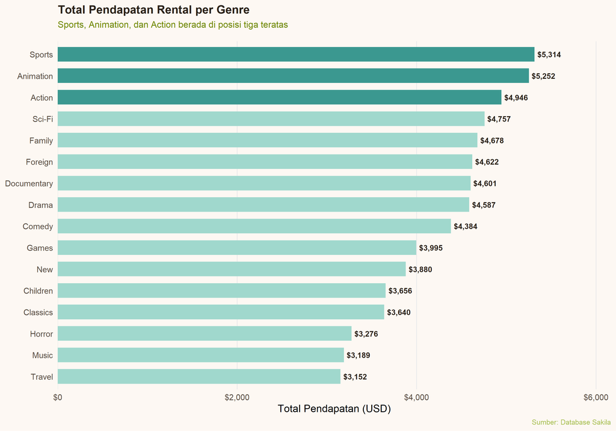

Gambar 1. Total Pendapatan Rental per Genre Film

```r
df_genre_sorted <- df_genre %>%
  arrange(desc(total_pendapatan)) %>%
  mutate(
    genre   = fct_reorder(genre, total_pendapatan),
    label   = dollar(total_pendapatan, accuracy = 1),
    is_top3 = row_number() <= 3
  )

ggplot(df_genre_sorted,
       aes(x = genre, y = total_pendapatan, fill = is_top3)) +
  geom_col(width = 0.68, show.legend = FALSE) +
  geom_text(aes(label = label), hjust = -0.12, size = 3.1,
            color = "#2a2118", fontface = "bold") +
  scale_fill_manual(values = c("FALSE" = "#A0D8CD", "TRUE" = "#3B9890")) +
  scale_y_continuous(labels = dollar_format(),
                     expand = expansion(mult = c(0, 0.16))) +
  coord_flip() +
  labs(title    = "Total Pendapatan Rental per Genre",
       subtitle = "Sports, Animation, dan Action berada di posisi tiga teratas",
       x = NULL, y = "Total Pendapatan (USD)",
       caption  = "Sumber: Database Sakila") +
  theme_minimal(base_size = 12, base_family = "sans") +
  theme(
    plot.title       = element_text(face = "bold", size = 13.5,
                                    color = "#2a2118"),
    plot.subtitle    = element_text(color = "#718804", size = 10.5,
                                    margin = margin(b = 14)),
    axis.text        = element_text(color = "#5a4e43"),
    panel.grid.major.y = element_blank(),
    panel.grid.minor   = element_blank(),
    plot.background  = element_rect(fill = "#fdf8f3", color = NA),
    panel.background = element_rect(fill = "#fdf8f3", color = NA),
    plot.caption     = element_text(color = "#A9BF53", size = 8.5)
  )
```

## 4.2 Visualisasi 2 — Tren Pendapatan Bulanan

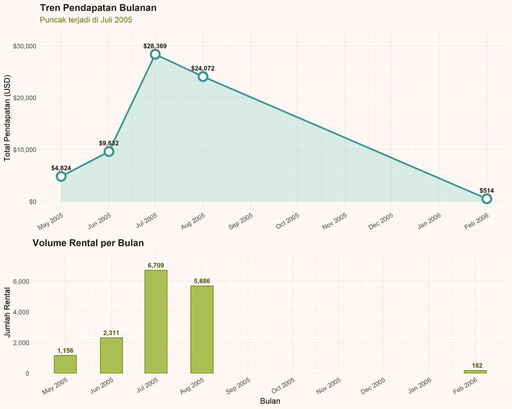

Gambar 2. Tren Pendapatan dan Volume Rental Bulanan

```r
df_bulanan <- df_bulanan %>%
  mutate(bulan_date = as.Date(paste0(bulan, "-01")))

p1 <- ggplot(df_bulanan, aes(x = bulan_date, y = total_pendapatan)) +
  geom_area(fill = "#A0D8CD", alpha = 0.4) +
  geom_line(color = "#3B9890", linewidth = 1.3) +
  geom_point(color = "#3B9890", size = 4.5, shape = 21,
             fill = "#fdf8f3", stroke = 2.2) +
  geom_text(aes(label = dollar(total_pendapatan, accuracy = 1)),
            vjust = -1.3, size = 3.2, color = "#2a2118", fontface = "bold") +
  scale_y_continuous(labels = dollar_format(),
                     expand = expansion(mult = c(0.05, 0.18))) +
  scale_x_date(date_labels = "%b %Y", date_breaks = "1 month") +
  labs(title = "Tren Pendapatan Bulanan",
       subtitle = "Puncak terjadi di Juli 2005",
       x = NULL, y = "Total Pendapatan (USD)") +
  theme_minimal(base_size = 11) +
  theme(
    plot.title       = element_text(face = "bold", color = "#2a2118"),
    plot.subtitle    = element_text(color = "#718804"),
    plot.background  = element_rect(fill = "#fdf8f3", color = NA),
    panel.background = element_rect(fill = "#fdf8f3", color = NA),
    axis.text.x      = element_text(angle = 30, hjust = 1, color = "#5a4e43")
  )

p2 <- ggplot(df_bulanan, aes(x = bulan_date, y = total_rental)) +
  geom_col(fill = "#A9BF53", color = "#718804", width = 15) +
  geom_text(aes(label = format(total_rental, big.mark = ",")),
            vjust = -0.6, size = 3.2, color = "#4a5c02", fontface = "bold") +
  scale_y_continuous(labels = comma_format(),
                     expand = expansion(mult = c(0, 0.18))) +
  scale_x_date(date_labels = "%b %Y", date_breaks = "1 month") +
  labs(title = "Volume Rental per Bulan",
       x = "Bulan", y = "Jumlah Rental") +
  theme_minimal(base_size = 11) +
  theme(
    plot.title       = element_text(face = "bold", color = "#2a2118"),
    plot.background  = element_rect(fill = "#fdf8f3", color = NA),
    panel.background = element_rect(fill = "#fdf8f3", color = NA),
    axis.text.x      = element_text(angle = 30, hjust = 1, color = "#5a4e43")
  )

grid.arrange(p1, p2, ncol = 1, heights = c(1.15, 0.85))
```

## 4.3 Visualisasi 3 — Korelasi Rental vs Pendapatan

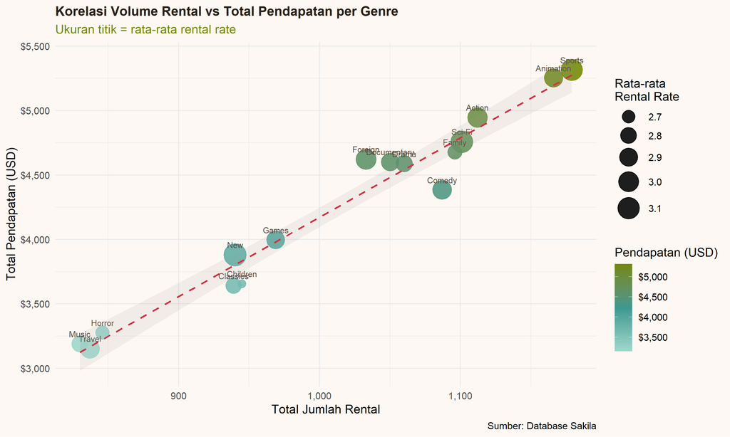

Gambar 3. Korelasi Volume Rental dan Total Pendapatan per Genre

```r
ggplot(df_genre,
       aes(x = total_rental, y = total_pendapatan,
           color = total_pendapatan, size = rata_rental_rate)) +
  geom_point(alpha = 0.88) +
  geom_text(aes(label = genre), vjust = -1.1, size = 2.9,
            color = "#5a4e43") +
  geom_smooth(method = "lm", se = TRUE, color = "#D33243",
              linetype = "dashed", linewidth = 0.8, alpha = 0.12,
              show.legend = FALSE) +
  scale_color_gradientn(colors = c("#A0D8CD","#3B9890","#718804"),
                        name = "Pendapatan (USD)",
                        labels = dollar_format()) +
  scale_size_continuous(name  = "Rata-rata\nRental Rate",
                        range = c(3.5, 10)) +
  scale_x_continuous(labels = comma_format()) +
  scale_y_continuous(labels = dollar_format()) +
  labs(title    = "Korelasi Volume Rental vs Total Pendapatan per Genre",
       subtitle = "Ukuran titik = rata-rata rental rate",
       x = "Total Jumlah Rental", y = "Total Pendapatan (USD)",
       caption = "Sumber: Database Sakila") +
  theme_minimal(base_size = 12) +
  theme(
    plot.title       = element_text(face = "bold", color = "#2a2118", size = 13),
    plot.subtitle    = element_text(color = "#718804"),
    plot.background  = element_rect(fill = "#fdf8f3", color = NA),
    panel.background = element_rect(fill = "#fdf8f3", color = NA),
    legend.background= element_rect(fill = "#fdf8f3", color = NA),
    legend.position  = "right"
  )
```

## 4.4 Visualisasi 4 — Distribusi Rating Film

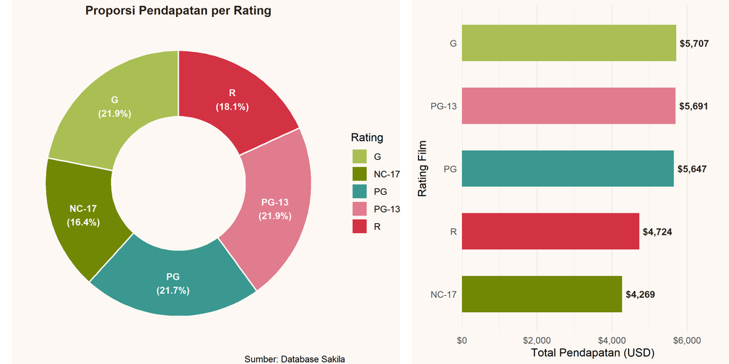

Gambar 4. Distribusi Pendapatan Berdasarkan Rating Film

```r
df_rating_agg <- df_rating %>%
  group_by(rating) %>%
  summarise(total_rental     = sum(total_rental),
            total_pendapatan = sum(total_pendapatan), .groups = "drop") %>%
  mutate(persen = total_pendapatan / sum(total_pendapatan) * 100,
         label  = sprintf("%s\n(%.1f%%)", rating, persen))

warna_rating <- c("G"     = "#A9BF53",
                  "PG"    = "#3B9890",
                  "PG-13" = "#E07C8E",
                  "R"     = "#D33243",
                  "NC-17" = "#718804")

p_donut <- ggplot(df_rating_agg,
                  aes(x = 2, y = total_pendapatan, fill = rating)) +
  geom_col(width = 1, color = "#fdf8f3", linewidth = 0.7) +
  geom_text(aes(label = label),
            position = position_stack(vjust = 0.5),
            size = 3.3, fontface = "bold", color = "white") +
  coord_polar(theta = "y") +
  xlim(0.5, 2.5) +
  scale_fill_manual(values = warna_rating, name = "Rating") +
  labs(title = "Proporsi Pendapatan per Rating",
       caption = "Sumber: Database Sakila") +
  theme_void() +
  theme(plot.title = element_text(face = "bold", color = "#2a2118",
                                  hjust = 0.5, size = 12),
        plot.background = element_rect(fill = "#fdf8f3", color = NA),
        legend.position = "right")

p_bar_r <- ggplot(df_rating_agg,
                  aes(x = fct_reorder(rating, total_pendapatan),
                      y = total_pendapatan, fill = rating)) +
  geom_col(width = 0.58, show.legend = FALSE) +
  geom_text(aes(label = dollar(total_pendapatan, accuracy = 1)),
            hjust = -0.12, size = 3.3, fontface = "bold",
            color = "#2a2118") +
  scale_fill_manual(values = warna_rating) +
  scale_y_continuous(labels = dollar_format(),
                     expand = expansion(mult = c(0, 0.22))) +
  coord_flip() +
  labs(x = "Rating Film", y = "Total Pendapatan (USD)") +
  theme_minimal(base_size = 11) +
  theme(panel.grid.major.y = element_blank(),
        plot.background    = element_rect(fill = "#fdf8f3", color = NA),
        panel.background   = element_rect(fill = "#fdf8f3", color = NA))

grid.arrange(p_donut, p_bar_r, ncol = 2, widths = c(1.3, 1))
```

## 4.5 Visualisasi 5 — Top 10 Film

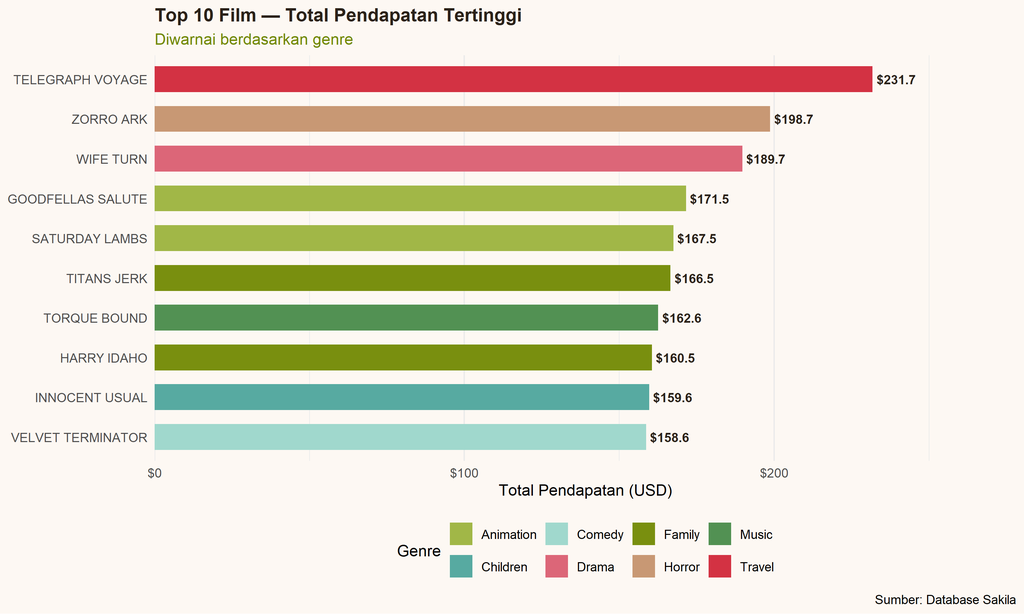

Gambar 5. Top 10 Film dengan Pendapatan Tertinggi

```r
warna_genre_top <- colorRampPalette(
  c("#D33243","#E07C8E","#A9BF53","#718804","#3B9890","#A0D8CD")
)(length(unique(df_top_film$genre)))

ggplot(df_top_film %>%
         mutate(title = fct_reorder(title, total_pendapatan)),
       aes(x = title, y = total_pendapatan, fill = genre)) +
  geom_col(width = 0.65) +
  geom_text(aes(label = dollar(total_pendapatan, accuracy = 0.1)),
            hjust = -0.1, size = 3.1, color = "#2a2118", fontface = "bold") +
  scale_fill_manual(values = setNames(warna_genre_top,
                                      unique(df_top_film$genre)),
                    name = "Genre") +
  scale_y_continuous(labels = dollar_format(),
                     expand = expansion(mult = c(0, 0.2))) +
  coord_flip() +
  labs(title    = "Top 10 Film — Total Pendapatan Tertinggi",
       subtitle = "Diwarnai berdasarkan genre",
       x = NULL, y = "Total Pendapatan (USD)",
       caption = "Sumber: Database Sakila") +
  theme_minimal(base_size = 11) +
  theme(
    plot.title         = element_text(face = "bold", color = "#2a2118", size = 13),
    plot.subtitle      = element_text(color = "#718804"),
    panel.grid.major.y = element_blank(),
    plot.background    = element_rect(fill = "#fdf8f3", color = NA),
    panel.background   = element_rect(fill = "#fdf8f3", color = NA),
    legend.background  = element_rect(fill = "#fdf8f3", color = NA),
    legend.position    = "bottom"
  )
```

# 5 Analisis Statistik

## 5.1 Analisis Korelasi

**Koefisien Korelasi Pearson:**

$$r = \frac{\sum_{i=1}^{n}(x_i -
\bar{x})(y_i - \bar{y})}{\sqrt{\sum_{i=1}^{n}(x_i - \bar{x})^2 \cdot
\sum_{i=1}^{n}(y_i - \bar{y})^2}}$$

di mana $x_i$ = jumlah rental, $y_i$ = total pendapatan untuk genre ke-$i$

```r
kor_test <- cor.test(df_genre$total_rental,
                     df_genre$total_pendapatan,
                     method = "pearson")

cat("=== UJI KORELASI PEARSON ===\n")
```

```
## === UJI KORELASI PEARSON ===
```

```r
cat(sprintf("Koefisien r  : %.4f\n", kor_test$estimate))
```

```
## Koefisien r  : 0.9820
```

```r
cat(sprintf("p-value      : %.6f\n", kor_test$p.value))
```

```
## p-value      : 0.000000
```

```r
cat(sprintf("95%% CI       : [%.4f, %.4f]\n",
            kor_test$conf.int[1], kor_test$conf.int[2]))
```

```
## 95% CI       : [0.9476, 0.9939]
```

```r
cat(sprintf("Kesimpulan   : %s\n",
            ifelse(kor_test$p.value < 0.05,
                   "Korelasi SIGNIFIKAN (p < 0.05)",
                   "Korelasi tidak signifikan")))
```

```
## Kesimpulan   : Korelasi SIGNIFIKAN (p < 0.05)
```